# Prediction Problem Report (Name of model (KNN / RF / Boosting / Ensemble); Regression / Classification)

```python
# host identity
identity_dummies = pd.get_dummies(train_imputed['host_identity_verified'], prefix = 'identity')
train_imputed = pd.concat([train_imputed, identity_dummies], axis = 1)

# for test
identity_dummies = pd.get_dummies(test_imputed['host_identity_verified'], prefix = 'identity')
test_imputed = pd.concat([test_imputed, identity_dummies], axis = 1)

# making a "dummy" variable for property type, room vs not room
train_imputed['property_room'] = train_imputed['property_type'].apply(lambda x: True if 'room' in x else False)

# you got it, for test
test_imputed['property_room'] = test_imputed['property_type'].apply(lambda x: True if 'room' in x else False)
# did not end up using this column because of a predictor created later

# do same as above but for the room type variable
train_imputed['room_room'] = train_imputed['room_type'].apply(lambda x: True if 'room' in x else False)

# anddddd, for test
test_imputed['room_room'] = test_imputed['room_type'].apply(lambda x: True if 'room' in x else False)

# Lets do ONE more for instant_bookable, for now
bookable_dummies = pd.get_dummies(train_imputed['instant_bookable'], prefix = 'bookable')
train_imputed = pd.concat([train_imputed, bookable_dummies], axis = 1)

# for test
bookable_dummies = pd.get_dummies(test_imputed['instant_bookable'], prefix = 'bookable')
test_imputed = pd.concat([test_imputed, bookable_dummies], axis = 1)

#### Editing Variables Now due to extreme values

# capping number_of_reviews at 2000, this may be a little dumb as I used log later but my model is still good
training = train_imputed.loc[train_imputed['number_of_reviews']<2000, :].copy()
training.shape

# we assign the values that were 0 negative one because these would be -infinity, but we don't want to make them 0 like the values of 1 are
# making some new variables
training['log_reviews'] = training['number_of_reviews'].apply(lambda x: np.log(x) if x != 0 else -1)
training['log_reviews_l30d'] = training['number_of_reviews_l30d'].apply(lambda x: np.log(x) if x != 0 else -1)
training['log_reviews_ltm'] = training['number_of_reviews_ltm'].apply(lambda x: np.log(x) if x != 0 else -1)

# for test
test_imputed['log_reviews'] = test_imputed['number_of_reviews'].apply(lambda x: np.log(x) if x != 0 else -1)
test_imputed['log_reviews_l30d'] = test_imputed['number_of_reviews_l30d'].apply(lambda x: np.log(x) if x != 0 else -1)
test_imputed['log_reviews_ltm'] = test_imputed['number_of_reviews_ltm'].apply(lambda x: np.log(x) if x != 0 else -1)

# New column for host listings being over or under 2000, and making sure value_counts have enough for both values
training['host_total_listings_over_2000'] = training['host_total_listings_count'].apply(lambda x: 'over 2000' if x > 2000 else 'under 2000')
test_imputed['host_total_listings_over_2000'] = test_imputed['host_total_listings_count'].apply(lambda x: 'over 2000' if x > 2000 else 'under 2000')
training['host_total_listings_over_2000'].value_counts()

# Well have to make some dummies for that previous added column, so we back!
# dummy variable for host_total over 2000
listings_dummy = pd.get_dummies(training['host_total_listings_over_2000'], prefix = 'listings')
training = pd.concat([training, listings_dummy], axis = 1)

# AND FOR TEST
listings_dummy = pd.get_dummies(test_imputed['host_total_listings_over_2000'], prefix = 'listings')
test_imputed = pd.concat([test_imputed, listings_dummy], axis = 1)

# Here we cap the maximum_nights_avg_ntm at 1125, which is the normal max and check that it worked
test_imputed.loc[test_imputed['maximum_nights_avg_ntm']>1125, 'maximum_nights_avg_ntm'] = 1125
test_imputed.loc[test_imputed['maximum_nights_avg_ntm']>1125]

training = training.loc[training['maximum_nights_avg_ntm'] < 1126, :].copy()

# removing points with a minimum nights under 600, felt like too much and there wasnt a great point to cap them at
training = training.loc[training['minimum_minimum_nights'] < 600, :].copy()
training.shape

# capping at above 400 as thats more than a year
training = training.loc[training['minimum_nights_avg_ntm'] < 400, :]
training.shape

# adding a log for reviews_per_month
training['reviews_per_month_log'] = np.log(training['reviews_per_month'])
test_imputed['reviews_per_month_log'] = np.log(test_imputed['reviews_per_month'])

#### Making Property Type better dummies

test_imputed.shape

value_counts = training['property_type'].value_counts()

property_50 = value_counts[value_counts > 50].index

training['property_room_cleansed'] = training['property_type'].apply(lambda x: x if x in property_50 else \
                                                                   'room' if 'room' in x else 'room_other' )

test_imputed['property_room_cleansed'] = test_imputed['property_type'].apply(lambda x: x if x in property_50 else \
                                                                   'room' if 'room' in x else 'room_other')

# making dummies for these
propertys = pd.get_dummies(training['property_room_cleansed'], drop_first=True)
training = pd.concat([training, propertys], axis = 1)

propertys = pd.get_dummies(test_imputed['property_room_cleansed'], drop_first=True)
test_imputed = pd.concat([test_imputed, propertys], axis = 1)


#### Making neighbourhood bins as well

# We also did based on large neighbourhoods here
value_counts = training['neighbourhood_cleansed'].value_counts()

neighbourhoods = value_counts[value_counts > 40].index

training['neighbourhoods'] = training['neighbourhood_cleansed'].apply(lambda x: x if x in neighbourhoods else 'neighborhood_other')
test_imputed['neighbourhoods'] = test_imputed['neighbourhood_cleansed'].apply(lambda x: x if x in neighbourhoods else 'neighborhood_other')

# making neighbourhood dummies based on this
neighbourhood = pd.get_dummies(training['neighbourhoods'])
training = pd.concat([training, neighbourhood], axis = 1)

# for test
neighbourhood = pd.get_dummies(test_imputed['neighbourhoods'])
test_imputed = pd.concat([test_imputed, neighbourhood], axis = 1)
```

```python
# Forgot to make dummies for these
# never made a dummy for host_response_time so doing that now
response_time_dummies = pd.get_dummies(training['host_response_time'])
training = pd.concat([training, response_time_dummies], axis = 1)

# and for test
response_time_dummies = pd.get_dummies(test_imputed['host_response_time'])
test_imputed = pd.concat([test_imputed, response_time_dummies], axis = 1)

test_imputed.loc[test_imputed['minimum_nights'] == 1125, 'minimum_nights'] = 100
test_imputed.loc[test_imputed['minimum_nights'] == 100, 'minimum_nights'] = 365

test_imputed.loc[test_imputed['minimum_nights_avg_ntm'] == 1125, 'minimum_nights_avg_ntm'] = 365

training.shape

test_imputed.shape

#### We should be ready to make the model now which I will also do here and comment out

training = training.reset_index().drop(columns = ['index'])
training.columns[:100]
```

```
Index(['id', 'host_id', 'host_since', 'host_location', 'host_response_time',
       'host_response_rate', 'host_acceptance_rate', 'host_is_superhost',
       'host_neighbourhood', 'host_listings_count',
       'host_total_listings_count', 'host_verifications',
       'host_has_profile_pic', 'host_identity_verified',
       'neighbourhood_cleansed', 'latitude', 'longitude', 'property_type',
       'room_type', 'accommodates', 'bathrooms_text', 'beds', 'price',
       'minimum_nights', 'maximum_nights', 'minimum_minimum_nights',
       'maximum_minimum_nights', 'minimum_maximum_nights',
       'maximum_maximum_nights', 'minimum_nights_avg_ntm',
       'maximum_nights_avg_ntm', 'has_availability', 'availability_30',
       'availability_60', 'availability_90', 'availability_365',
       'number_of_reviews', 'number_of_reviews_ltm', 'number_of_reviews_l30d',
       'first_review', 'last_review', 'review_scores_rating',
       'review_scores_accuracy', 'review_scores_cleanliness',
       'review_scores_checkin', 'review_scores_communication',
       'review_scores_location', 'review_scores_value', 'instant_bookable',
       'calculated_host_listings_count',
       'calculated_host_listings_count_entire_homes',
       'calculated_host_listings_count_private_rooms',
       'calculated_host_listings_count_shared_rooms', 'reviews_per_month',
       'log_price', 'baths', 'host_days_since', 'days_since_first',
       'days_since_last', 'neighborhood_price_bins', 'low_price_hood',
       'below_average_price_hood', 'average_price_hood',
       'above_average_price_hood', 'high_price_hood', 'superhost_f',
       'superhost_t', 'profile_f', 'profile_t',
       'verifications_['email', 'phone', 'work_email']',
       'verifications_['email', 'phone']', 'verifications_['email']',
       'verifications_['phone', 'work_email']', 'verifications_['phone']',
       'identity_f', 'identity_t', 'property_room', 'room_room', 'bookable_f',
       'bookable_t', 'log_reviews', 'log_reviews_l30d', 'log_reviews_ltm',
       'host_total_listings_over_2000', 'listings_over 2000',
       'listings_under 2000', 'reviews_per_month_log',
       'property_room_cleansed', 'Entire guest suite', 'Entire home',
       'Entire rental unit', 'Entire serviced apartment', 'Entire townhouse',
       'Private room in condo', 'Private room in home',
       'Private room in rental unit', 'Room in hotel', 'room', 'room_other',
       'neighbourhoods'],
      dtype='object')
```

```python
def calculate_adjusted_averages(df, group_col, price_col):
    group_avg = df.groupby(group_col)[price_col].mean()
    overall_mean = group_avg.mean()
    adjusted_avg = {}

    for group in group_avg.index:
        count = np.sum(df[group_col] == group)
        adjusted_value = ((count * group_avg[group]) + overall_mean) / (count + 1)
        adjusted_avg[group] = adjusted_value

    return pd.Series(adjusted_avg)

# Calculate adjusted averages for property_room_cleansed
property_avg_adjusted = calculate_adjusted_averages(training, 'property_room_cleansed', 'price')

# Map these adjusted averages back to the DataFrames
training['property_averages'] = training['property_room_cleansed'].map(property_avg_adjusted)
test_imputed['property_averages'] = test_imputed['property_room_cleansed'].map(property_avg_adjusted)
test_imputed['property_averages'] = test_imputed['property_averages'].fillna(property_avg_adjusted.mean())

# Calculate adjusted averages for room_type
rooms_avg_adjusted = calculate_adjusted_averages(training, 'room_type', 'price')

# Map these adjusted averages back to the DataFrames
training['room_averages'] = training['room_type'].map(rooms_avg_adjusted)
test_imputed['room_averages'] = test_imputed['room_type'].map(rooms_avg_adjusted)
test_imputed['room_averages'] = test_imputed['room_averages'].fillna(rooms_avg_adjusted.mean())
```

```python
train_tested = training.copy()
test_tested = test_imputed.copy()
```

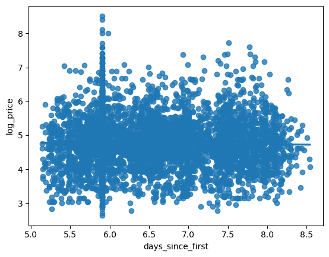

```python
sns.regplot(x = np.log(training['days_since_first']), y = training['log_price'])
```

```python
# exponentiate columns with small values, log columns with bag values
# Keep all for lasso model, keep just regular for
#review scores
training['review_scores_accuracy_exp'] = np.exp(training['review_scores_accuracy'])
training['review_scores_checkin_exp'] = np.exp(training['review_scores_checkin'])
training['review_scores_cleanliness_exp'] = np.exp(training['review_scores_cleanliness'])
training['review_scores_communication_exp'] = np.exp(training['review_scores_communication'])
training['review_scores_location_exp'] = np.exp(training['review_scores_location'])
training['review_scores_rating_exp'] = np.exp(training['review_scores_rating'])
training['review_scores_value_exp'] = np.exp(training['review_scores_value'])

# min and max nights
training['minimum_nights_log'] = training['minimum_nights'].apply(lambda x: np.log(x) if x >0 else -1)
training['minimum_nights_avg_ntm_log'] = training['minimum_nights_avg_ntm'].apply(lambda x: np.log(x) if x >0 else -1)
training['maximum_nights_log'] = training['maximum_nights'].apply(lambda x: np.log(x) if x >0 else -1)
training['maximum_nights_avg_ntm_log'] = training['maximum_nights_avg_ntm'].apply(lambda x: np.log(x) if x >0 else -1)

# calculated host listings count
training['calculated_host_listings_count_log'] = training['calculated_host_listings_count'].apply(lambda x: \
                                                                                                 np.log(x) if x>0 else -1)

# days stuff
training['host_days_since_log'] = np.log(training['host_days_since'])
training['days_since_first_log'] = np.log(training['days_since_first'])
training['days_since_last_log'] = np.log(training['days_since_last'])




test_imputed['review_scores_accuracy_exp'] = np.exp(test_imputed['review_scores_accuracy'])
test_imputed['review_scores_checkin_exp'] = np.exp(test_imputed['review_scores_checkin'])
test_imputed['review_scores_cleanliness_exp'] = np.exp(test_imputed['review_scores_cleanliness'])
test_imputed['review_scores_communication_exp'] = np.exp(test_imputed['review_scores_communication'])
test_imputed['review_scores_location_exp'] = np.exp(test_imputed['review_scores_location'])
test_imputed['review_scores_rating_exp'] = np.exp(test_imputed['review_scores_rating'])
test_imputed['review_scores_value_exp'] = np.exp(test_imputed['review_scores_value'])

test_imputed['minimum_nights_log'] = test_imputed['minimum_nights'].apply(lambda x: np.log(x) if x >0 else -1)
test_imputed['minimum_nights_avg_ntm_log'] = test_imputed['minimum_nights_avg_ntm'].apply(lambda x: np.log(x) if x >0 else -1)
test_imputed['maximum_nights_log'] = test_imputed['maximum_nights'].apply(lambda x: np.log(x) if x >0 else -1)
test_imputed['maximum_nights_avg_ntm_log'] = test_imputed['maximum_nights_avg_ntm'].apply(lambda x: np.log(x) if x >0 else -1)

test_imputed['calculated_host_listings_count_log'] = test_imputed['calculated_host_listings_count'].apply(lambda x: \
                                                                                                 np.log(x) if x>0 else -1)

test_imputed['host_days_since_log'] = np.log(test_imputed['host_days_since'])
test_imputed['days_since_first_log'] = np.log(test_imputed['days_since_first'])
test_imputed['days_since_last_log'] = np.log(test_imputed['days_since_last'])
```

```python
training.loc[:, ['review_scores_accuracy', 'review_scores_accuracy_exp', 'review_scores_checkin_exp', 'review_scores_checkin', \
                'review_scores_cleanliness_exp', 'review_scores_cleanliness', 'review_scores_communication_exp',\
                'review_scores_communication', 'review_scores_location_exp', 'review_scores_location', \
                'review_scores_rating_exp', 'review_scores_rating', 'review_scores_value_exp', 'review_scores_value']].corrwith(training['log_price'])
```

```
review_scores_accuracy             0.103137
review_scores_accuracy_exp         0.141500
review_scores_checkin_exp          0.101514
review_scores_checkin              0.069105
review_scores_cleanliness_exp      0.188202
review_scores_cleanliness          0.153673
review_scores_communication_exp    0.102708
review_scores_communication        0.072467
review_scores_location_exp         0.222475
review_scores_location             0.177592
review_scores_rating_exp           0.175007
review_scores_rating               0.129496
review_scores_value_exp            0.073717
review_scores_value                0.068495
dtype: float64
```

```python
training.head()
```

|  | id | host_id | host_since | host_location | host_response_time | host_response_rate | host_acceptance_rate | host_is_superhost | host_neighbourhood | host_listings_count | ... | review_scores_rating_exp | review_scores_value_exp | minimum_nights_log | minimum_nights_avg_ntm_log | maximum_nights_log | maximum_nights_avg_ntm_log | calculated_host_listings_count_log | host_days_since_log | days_since_first_log | days_since_last_log |
| --- | --- | --- | --- | --- | --- | --- | --- | --- | --- | --- | --- | --- | --- | --- | --- | --- | --- | --- | --- | --- | --- |
| 0 | 53872917 | 366516391 | 2018-04-09 | Chicago, IL | within an hour | 96.0 | 95.0 | f | Back of the Yards | 11 | ... | 139.770250 | 125.210961 | 3.465736 | 3.465736 | 7.025538 | 7.025538 | 2.197225 | 7.718241 | 7.504392 | 6.496775 |
| 1 | 39269663 | 50276775 | 2014-12-23 | Chicago, IL | within an hour | 100.0 | 97.0 | f | Clearwater Beach | 1141 | ... | 116.687243 | 106.524008 | 3.465736 | 3.465736 | 5.899897 | 5.899897 | 4.060443 | 8.146709 | 5.905362 | 5.257495 |
| 2 | 556480733030442463 | 681680651 | 2020-03-08 | Chicago, IL | within an hour | 100.0 | 100.0 | f | Lake View East | 1 | ... | 130.320917 | 121.510418 | 0.693147 | 0.693147 | 3.806662 | 3.806662 | 0.000000 | 7.346010 | 5.768321 | 5.220356 |
| 3 | 52397280 | 94345291 | 2015-10-22 | Chicago, IL | within an hour | 100.0 | 98.0 | f | Bucktown | 55 | ... | 59.145470 | 46.993063 | 0.693147 | 0.693147 | 5.192957 | 5.192957 | 4.007333 | 8.054840 | 5.624018 | 5.204007 |
| 4 | 745949202271858960 | 790998106 | 2021-04-04 | Chicago, IL | within an hour | 100.0 | 100.0 | t | Near South Side | 74 | ... | 121.510418 | 112.168253 | 0.693147 | 0.693147 | 5.899897 | 7.025538 | 4.304065 | 7.054450 | 6.634633 | 5.204007 |

5 rows × 149 columns

### Model for price

```python
# This is the improved
X_train = training.drop(columns = ['id', 'host_id', 'host_location', 'host_since', 'host_is_superhost', 'host_response_time',\
                                  'host_neighbourhood', 'host_listings_count', 'host_total_listings_count', 'host_verifications',\
                                  'host_has_profile_pic', 'host_identity_verified', 'neighbourhood_cleansed', 'property_type', \
                                 'room_type', 'bathrooms_text', 'price', 'log_price', 'minimum_minimum_nights', 'minimum_maximum_nights', \
                                   'maximum_maximum_nights', 'maximum_minimum_nights', 'has_availability', 'first_review', 'last_review', \
                                   'instant_bookable', 'reviews_per_month', 'calculated_host_listings_count_private_rooms', 'calculated_host_listings_count_shared_rooms',\
                             'neighborhood_price_bins', 'host_total_listings_over_2000',
                                  "verifications_['email', 'phone', 'work_email']", "verifications_['email', 'phone']", \
                                  "verifications_['email']", "verifications_['phone', 'work_email']", "verifications_['phone']", \
                                 'calculated_host_listings_count_entire_homes', \
                                  'property_room_cleansed', 'neighbourhoods', 'within a day', 'within a few hours', 'within an hour'])
X_test = test_imputed.drop(columns = ['id', 'host_id', 'host_location', 'host_since', 'host_is_superhost', 'host_response_time',\
                                  'host_neighbourhood', 'host_listings_count', 'host_total_listings_count', 'host_verifications',\
                                  'host_has_profile_pic', 'host_identity_verified', 'neighbourhood_cleansed', 'property_type', \
                                 'room_type', 'bathrooms_text', 'price', 'log_price', 'minimum_minimum_nights', 'minimum_maximum_nights', \
                                   'maximum_maximum_nights', 'maximum_minimum_nights', 'has_availability', 'first_review', 'last_review', \
                                   'instant_bookable', 'reviews_per_month', 'calculated_host_listings_count_private_rooms', 'calculated_host_listings_count_shared_rooms',\
                             'neighborhood_price_bins', 'host_total_listings_over_2000',
                                  "verifications_['email', 'phone', 'work_email']", "verifications_['email', 'phone']", \
                                  "verifications_['email']", "verifications_['phone', 'work_email']", "verifications_['phone']", \
                                 'calculated_host_listings_count_entire_homes', \
                                  'property_room_cleansed', 'neighbourhoods', 'within a day', 'within a few hours', 'within an hour'])
scaler = StandardScaler()
X_train_scaled = scaler.fit_transform(X_train)
X_test = X_test.loc[:, X_train.columns]
X_test_scaled = scaler.transform(X_test)
```

```python
names = X_train.columns
# Convertin Xstd to dataframes
boost_train = pd.DataFrame(X_train_scaled, columns=names)
boost_test = pd.DataFrame(X_test_scaled, columns=names)
# dropping every column whose values are only 0, should make code run much faster as well
#train_std = train_Xstd.drop(train_Xstd.columns[(train_Xstd == 0).all()], axis=1)
#test_std = test_Xstd.drop(test_Xstd.columns[(test_Xstd == 0).all()], axis=1)
boost_train.head()
```

|  | host_response_rate | host_acceptance_rate | latitude | longitude | accommodates | beds | minimum_nights | maximum_nights | minimum_nights_avg_ntm | maximum_nights_avg_ntm | ... | review_scores_rating_exp | review_scores_value_exp | minimum_nights_log | minimum_nights_avg_ntm_log | maximum_nights_log | maximum_nights_avg_ntm_log | calculated_host_listings_count_log | host_days_since_log | days_since_first_log | days_since_last_log |
| --- | --- | --- | --- | --- | --- | --- | --- | --- | --- | --- | --- | --- | --- | --- | --- | --- | --- | --- | --- | --- | --- |
| 0 | -0.149014 | 0.199645 | -1.554284 | 0.005301 | -1.096572 | -0.750474 | 0.688501 | 1.275527 | -0.070760 | 0.764500 | ... | 0.738542 | 0.516117 | 1.242441 | 0.888843 | 0.943637 | 0.616875 | 0.201450 | 0.137143 | 1.164275 | 2.113347 |
| 1 | 0.226508 | 0.312429 | 0.015673 | 0.924270 | 2.462665 | 0.411489 | 0.688501 | -0.435699 | -0.070760 | -0.997418 | ... | -0.191537 | -0.207418 | 1.242441 | 0.888843 | 0.126788 | -0.338146 | 1.203080 | 0.755782 | -0.826017 | -0.461182 |
| 2 | 0.226508 | 0.481605 | 0.898762 | 0.210279 | 0.521263 | 0.411489 | -0.489808 | -1.156216 | -0.397791 | -1.739278 | ... | 0.357802 | 0.372836 | -0.631551 | -0.784652 | -1.392220 | -2.114096 | -0.979734 | -0.400299 | -0.996590 | -0.538338 |
| 3 | 0.226508 | 0.368821 | -1.446071 | 1.456436 | -0.773005 | -0.750474 | -0.489808 | -0.852248 | -0.397791 | -1.426305 | ... | -2.510055 | -2.512379 | -0.631551 | -0.784652 | -0.386221 | -0.937931 | 1.174529 | 0.623138 | -1.176203 | -0.572302 |
| 4 | 0.226508 | 0.481605 | -0.573669 | 0.847013 | 0.521263 | 0.411489 | -0.489808 | -0.435699 | -0.397791 | 0.764500 | ... | 0.002802 | 0.011120 | -0.631551 | -0.784652 | 0.126788 | 0.616875 | 1.334046 | -0.821265 | 0.081698 | -0.572302 |

5 rows × 107 columns

```python
y = training['price']
```

```python
#K-fold cross validation to find optimal parameters for CatBoost regressor
param_grid = {'num_leaves': [55, 60, 65],
              'learning_rate': [0.02, 0.025, 0.03, .035, .04],
               'reg_lambda':[4,5,6],
                'n_estimators':[2500, 2750, 3000, 3250, 3500],
                'subsample': [.85, .875, .9, .925, .95],
             'colsample_bylevel': [.25, .275, 0.3, .325, .35, .4]}

cv = KFold(n_splits=5,shuffle=True,random_state=1)
optimal_params = RandomizedSearchCV(estimator=CatBoostRegressor(random_state=1, verbose=False,
                            grow_policy='Lossguide', thread_count = -1),
                             param_distributions = param_grid, n_iter = 50,
                             verbose = 3,random_state = 1, scoring='neg_root_mean_squared_error',
                             cv = cv)
optimal_params.fit(boost_train,y)
print("Optimal parameter values =", optimal_params.best_params_)
print("Optimal cross validation RMSE = ",optimal_params.best_score_)
```

```
Fitting 5 folds for each of 50 candidates, totalling 250 fits
[CV 1/5] END colsample_bylevel=0.35, learning_rate=0.03, n_estimators=3500, num_leaves=60, reg_lambda=6, subsample=0.9;, score=-97.186 total time=  57.1s
[CV 2/5] END colsample_bylevel=0.35, learning_rate=0.03, n_estimators=3500, num_leaves=60, reg_lambda=6, subsample=0.9;, score=-124.760 total time=  52.0s
[CV 3/5] END colsample_bylevel=0.35, learning_rate=0.03, n_estimators=3500, num_leaves=60, reg_lambda=6, subsample=0.9;, score=-181.103 total time=  59.8s
[CV 4/5] END colsample_bylevel=0.35, learning_rate=0.03, n_estimators=3500, num_leaves=60, reg_lambda=6, subsample=0.9;, score=-155.615 total time=  54.2s
[CV 5/5] END colsample_bylevel=0.35, learning_rate=0.03, n_estimators=3500, num_leaves=60, reg_lambda=6, subsample=0.9;, score=-112.162 total time=  57.2s
[CV 1/5] END colsample_bylevel=0.25, learning_rate=0.025, n_estimators=2500, num_leaves=55, reg_lambda=6, subsample=0.85;, score=-96.142 total time=  38.2s
[CV 2/5] END colsample_bylevel=0.25, learning_rate=0.025, n_estimators=2500, num_leaves=55, reg_lambda=6, subsample=0.85;, score=-114.367 total time=  38.4s
[CV 3/5] END colsample_bylevel=0.25, learning_rate=0.025, n_estimators=2500, num_leaves=55, reg_lambda=6, subsample=0.85;, score=-178.251 total time=  40.2s
[CV 4/5] END colsample_bylevel=0.25, learning_rate=0.025, n_estimators=2500, num_leaves=55, reg_lambda=6, subsample=0.85;, score=-157.139 total time=  40.9s
[CV 5/5] END colsample_bylevel=0.25, learning_rate=0.025, n_estimators=2500, num_leaves=55, reg_lambda=6, subsample=0.85;, score=-111.341 total time=  39.3s
[CV 1/5] END colsample_bylevel=0.325, learning_rate=0.03, n_estimators=3250, num_leaves=60, reg_lambda=5, subsample=0.85;, score=-97.226 total time=  54.7s
[CV 2/5] END colsample_bylevel=0.325, learning_rate=0.03, n_estimators=3250, num_leaves=60, reg_lambda=5, subsample=0.85;, score=-119.604 total time=  55.7s
[CV 3/5] END colsample_bylevel=0.325, learning_rate=0.03, n_estimators=3250, num_leaves=60, reg_lambda=5, subsample=0.85;, score=-177.866 total time=  54.7s
[CV 4/5] END colsample_bylevel=0.325, learning_rate=0.03, n_estimators=3250, num_leaves=60, reg_lambda=5, subsample=0.85;, score=-157.080 total time=  55.8s
[CV 5/5] END colsample_bylevel=0.325, learning_rate=0.03, n_estimators=3250, num_leaves=60, reg_lambda=5, subsample=0.85;, score=-112.918 total time=  51.3s
[CV 1/5] END colsample_bylevel=0.35, learning_rate=0.035, n_estimators=2500, num_leaves=60, reg_lambda=4, subsample=0.9;, score=-97.177 total time=  40.6s
[CV 2/5] END colsample_bylevel=0.35, learning_rate=0.035, n_estimators=2500, num_leaves=60, reg_lambda=4, subsample=0.9;, score=-120.331 total time=  42.2s
[CV 3/5] END colsample_bylevel=0.35, learning_rate=0.035, n_estimators=2500, num_leaves=60, reg_lambda=4, subsample=0.9;, score=-181.777 total time=  43.5s
[CV 4/5] END colsample_bylevel=0.35, learning_rate=0.035, n_estimators=2500, num_leaves=60, reg_lambda=4, subsample=0.9;, score=-156.708 total time=  42.1s
[CV 5/5] END colsample_bylevel=0.35, learning_rate=0.035, n_estimators=2500, num_leaves=60, reg_lambda=4, subsample=0.9;, score=-113.088 total time=  42.0s
[CV 1/5] END colsample_bylevel=0.25, learning_rate=0.04, n_estimators=2500, num_leaves=55, reg_lambda=5, subsample=0.85;, score=-92.353 total time=  37.3s
[CV 2/5] END colsample_bylevel=0.25, learning_rate=0.04, n_estimators=2500, num_leaves=55, reg_lambda=5, subsample=0.85;, score=-118.081 total time=  36.6s
[CV 3/5] END colsample_bylevel=0.25, learning_rate=0.04, n_estimators=2500, num_leaves=55, reg_lambda=5, subsample=0.85;, score=-178.867 total time=  37.8s
[CV 4/5] END colsample_bylevel=0.25, learning_rate=0.04, n_estimators=2500, num_leaves=55, reg_lambda=5, subsample=0.85;, score=-155.826 total time=  38.4s
[CV 5/5] END colsample_bylevel=0.25, learning_rate=0.04, n_estimators=2500, num_leaves=55, reg_lambda=5, subsample=0.85;, score=-111.701 total time=  38.4s
```

[output cut: 227 more lines]

Optimal parameter values = {‘subsample’: 0.85, ‘reg_lambda’: 5, ‘num_leaves’: 55, ‘n_estimators’: 2500, ‘learning_rate’: 0.04, ‘colsample_bylevel’: 0.25}

```python
cbc1 = CatBoostRegressor(subsample = .875, reg_lambda = 10, n_estimators = 2500, max_depth = 6, learning_rate = .04, \
                    colsample_bylevel= .625, early_stopping_rounds=40, random_state=1, verbose=False, \
                            grow_policy='Lossguide').fit(boost_train, y)
```

```python
np.where(cat_boost.feature_importances_<.005)
```

[output not shown]

```python
boost_train_less = boost_train.iloc[:, np.where(cat_boost.feature_importances_>.005)[0]]
boost_test_less = boost_test.iloc[:, np.where(cat_boost.feature_importances_>.005)[0]]
```

```python
cat_boost = CatBoostRegressor(verbose = False, random_state=1).fit(boost_train_less, y)
```

```python
np.sort(cat_boost.feature_importances_)
```

```
array([9.94036767e-03, 1.53429182e-02, 1.55007095e-02, 1.88947188e-02,
       2.11902508e-02, 2.82727561e-02, 3.06366121e-02, 3.83052494e-02,
       5.31979248e-02, 5.97418374e-02, 6.38307785e-02, 7.40056944e-02,
       1.24956391e-01, 1.25170584e-01, 1.74965838e-01, 2.12209046e-01,
       2.40419720e-01, 2.47315529e-01, 3.11626784e-01, 4.62804561e-01,
       4.90159367e-01, 5.09544834e-01, 5.61465667e-01, 5.65667417e-01,
       5.93795609e-01, 6.87348307e-01, 8.45662523e-01, 8.52815947e-01,
       1.07782517e+00, 1.11191643e+00, 1.20377455e+00, 1.23030177e+00,
       1.23996378e+00, 1.31498308e+00, 1.31902405e+00, 1.49102077e+00,
       1.70587861e+00, 1.74826310e+00, 1.81642973e+00, 2.00558447e+00,
       2.09987291e+00, 2.24769142e+00, 2.45974633e+00, 2.46649454e+00,
       2.54282128e+00, 3.07799418e+00, 4.25940353e+00, 4.51409289e+00,
       5.01513846e+00, 7.84918392e+00, 1.53332944e+01, 2.34345127e+01])
```

```python
boost_train.iloc[:, 18]
```

```
0      -0.522021
1       1.959694
2      -0.522021
3      -0.522021
4       0.718837
          ...
4982   -0.522021
4983   -0.522021
4984   -0.522021
4985   -0.522021
4986    0.718837
Name: baths, Length: 4987, dtype: float64
```

```python
cat_prediction = cbc1.predict(boost_test)
```

```python
cat_prediction.mean()
```

```
156.9162340745549
```

```python
cat_prediction.max()
```

```
1728.4157075854025
```

```python
#K-fold cross validation to find optimal parameters for CatBoost regressor
param_grid = {'learning_rate': [0.03, 0.05, .07],
               'reg_lambda':[1 ,3, 5, 7, 9],
                'n_estimators':[3000, 3500, 4000, 4500, 5000],
                'subsample': [.7, .8, .9, 1.0],
             'colsample_bylevel': [.2, .25, 0.3, .35, .4]}

cv = KFold(n_splits=5,shuffle=True,random_state=1)
optimal_params = RandomizedSearchCV(estimator=CatBoostRegressor(random_state=1, verbose=False,
                            grow_policy='SymmetricTree', thread_count = -1),
                             param_distributions = param_grid, n_iter = 100,
                             verbose = 3,random_state = 1, scoring='neg_root_mean_squared_error',
                             n_jobs=-1,
                             cv = cv)
optimal_params.fit(boost_train,y)
print("Optimal parameter values =", optimal_params.best_params_)
print("Optimal cross validation RMSE = ",optimal_params.best_score_)
```

[output not shown]

```
Fitting 5 folds for each of 100 candidates, totalling 500 fits
```

```python
rfr = RandomForestRegressor(n_estimators = 1000).fit(boost_train, y)
```

```python
boost_train_less = boost_train.iloc[:, np.where(rfr.feature_importances_ > .001)[0]]
boost_test_less = boost_test.iloc[:, np.where(rfr.feature_importances_ > .001)[0]]
```

```python
boost_train_less.shape
```

```
(4987, 63)
```

```python
boost_train.shape
```

```
(4987, 107)
```

```python
cat_lossguide = CatBoostRegressor(random_state=1, verbose = False, grow_policy='Lossguide', \
                                       subsample = .975, reg_lambda=2, num_leaves = 60, n_estimators = 2625, \
                                       learning_rate = 0.035, colsample_bylevel = .275)
```

```python
-np.mean(cross_val_score(cat_lossguide, boost_train_less, y, cv = 5, scoring='neg_root_mean_squared_error', n_jobs=-1))
```

```
133.479006187734
```

```python
cat_symmetric = CatBoostRegressor(random_state=1, verbose = False, grow_policy='SymmetricTree', \
                                       subsample = .925, reg_lambda=3, n_estimators = 2500, \
                                       learning_rate = 0.05, colsample_bylevel = .175)
```

```python
-np.mean(cross_val_score(cat_symmetric, boost_train_less, y, cv = 5, scoring='neg_root_mean_squared_error', n_jobs=-1))
```

```
KeyboardInterrupt:
```

```python
exgb = xgb.XGBRegressor(random_state = 1, colsample_bytree = 0.6900874555638847, gamma = 0, learning_rate = .1, \
                       max_leaves = 65, n_estimators = 5000, reg_lambda = 523.7949204746988, subsample = .3)
```

```python
-np.mean(cross_val_score(exgb, boost_train_less, y, cv = 5, scoring='neg_root_mean_squared_error', n_jobs=-1))
```

```python
cat_lossguide = CatBoostRegressor(random_state=1, verbose = False, grow_policy='Lossguide', \
                                       subsample = .975, reg_lambda=2, num_leaves = 60, n_estimators = 2625, \
                                       learning_rate = 0.035, colsample_bylevel = .275).fit(boost_train_less, y)
```

```python
cat_loss_pred = cat_lossguide.predict(boost_test)
```

```python
cat_symmetric =CatBoostRegressor(random_state=1, verbose = False, grow_policy='SymmetricTree', \
                                       subsample = .925, reg_lambda=3, n_estimators = 2500, \
                                       learning_rate = 0.05, colsample_bylevel = .175).fit(boost_train_less, y)
```

```python
cat_sym_pred = cat_symmetric.predict(boost_test)
```

```python
exgb = xgb.XGBRegressor(random_state = 1, colsample_bytree = 0.6900874555638847, gamma = 0, learning_rate = .1, \
                       max_leaves = 65, n_estimators = 5000, reg_lambda = 523.7949204746988, subsample = .3).fit(boost_train_less, y)
```

```python
exgb_pred = exgb.predict(boost_test_less)
```

```python
root_mean_squared_error(exgb_pred, cat_sym_pred)
```

```
39.266858854096256
```

```python
stack_cat.final_estimator_.coef_
```

[output not shown]

```python
stack_cat.final_estimator_.intercept_
```

```
-3.952282862739935
```

```python
stack_cat_pred = stack_cat.predict(boost_test_less)
```

```python
stack_cat_pred.mean()
```

```
153.16345403639681
```

## 2) Hyperparameter tuning

### How many attempts did it take you to tune the model hyperparameters?

So. Many. Times. I really struggled with making my model with this one, and am still working on it now honestly. I ended up tuning 2 catboost models and one xgboost(the catboost were different in one used symmetric trees, one used lossguide). For just these models, took maybe 5-7 attempts each as I narrowed them down a good amount and also changed predictors I tuned them on a couple times.

### Which tuning method did you use (grid search / Bayes search / etc.)?

I used RandomSearch and BayesSearch.

### What challenges did you face while tuning the hyperparameters, and what actions did you take to address those challenges?

Using Quest was huge for me, allowing me to tune faster and also do either other coding or just other work in the background. Aside from that the main challenges I faced was just that I felt my models were not doing nearly well enough. I think it has to do with the predictors I was using but I am unsure.

### How many hours did you spend on hyperparameter tuning?

Uncountable.

**Paste the hyperparameter tuning code below. You must show at least one hyperparameter tuning procedure.**

The optimal are below in my model

## 3) Model

Using the optimal model hyperparameters, train the model, and paste the code below.

```python
cat_lossguide = CatBoostRegressor(random_state=1, verbose = False, grow_policy='Lossguide', \
                                       subsample = .975, reg_lambda=2, num_leaves = 60, n_estimators = 2625, \
                                       learning_rate = 0.035, colsample_bylevel = .275)
cat_symmetric =CatBoostRegressor(random_state=1, verbose = False, grow_policy='SymmetricTree', \
                                       subsample = .925, reg_lambda=3, n_estimators = 2500, \
                                       learning_rate = 0.05, colsample_bylevel = .175)
exgb = xgb.XGBRegressor(random_state = 1, colsample_bytree = 0.6900874555638847, gamma = 0, learning_rate = .1, \
                       max_leaves = 65, n_estimators = 5000, reg_lambda = 523.7949204746988, subsample = .3)
cv = KFold(n_splits=5, random_state=1, shuffle=True)

stack_cat = StackingRegressor([('lossguide', cat_lossguide), ('symmetric', cat_symmetric), ('exgb', exgb)],\
                              final_estimator= LinearRegression(), \
                             cv=cv, n_jobs=-1)
stack_cat.fit(boost_train_less, y)
```

```python
stack_cat.final_estimator_.coef_
```

```python
stack_cat_pred = stack_cat.predict(boost_test_less)
```

```python
stack_cat_pred.mean()
```

## 4) Put any ad-hoc steps for further improving model accuracy

For example, scaling up or scaling down the predictions, capping predictions, etc.

Put code below.

##### My ad hoc steps are a whole nother model so I’ll put it all here

```python
poly = PolynomialFeatures(2, include_bias = False)
# these are the total variables to be dropped
# This is the improved
X_train_log = training.drop(columns = ['id', 'host_id', 'host_since', 'host_location', 'host_response_time', 'host_is_superhost', \
                                  'host_neighbourhood', 'host_listings_count', 'host_total_listings_count', 'host_verifications', \
                                   'host_has_profile_pic', 'host_identity_verified', 'neighbourhood_cleansed', 'property_type', \
                                   'room_type', 'bathrooms_text', 'price', 'minimum_minimum_nights', 'maximum_minimum_nights', \
                                   'minimum_maximum_nights', 'maximum_maximum_nights', 'has_availability', 'first_review', \
                                   'last_review', 'instant_bookable', 'calculated_host_listings_count_entire_homes', \
                                   'calculated_host_listings_count_private_rooms', \
                                   'calculated_host_listings_count_shared_rooms', 'log_price', 'host_total_listings_over_2000', \
                                   'property_room_cleansed', 'neighbourhoods', 'superhost_t', 'profile_t', 'identity_f', \
                                      'bookable_f', 'listings_under 2000', 'Armour Square', \
                                      'a few days or more', 'within a day', 'Avondale', 'Bridgeport', 'Douglas', 'East Garfield Park', 'Edgewater',
       'Grand Boulevard', 'Humboldt Park', 'Hyde Park', 'Irving Park',
       'Lake View', 'Lincoln Park', 'Lincoln Square', 'Logan Square', 'Loop',
       'Lower West Side', 'Near North Side', 'Near South Side', 'neighborhood_price_bins', \
       'Near West Side', 'North Center', 'Portage Park', 'Rogers Park',
       'South Shore', 'Uptown', 'West Ridge', 'West Town', 'Woodlawn', 'within a few hours', 'within an hour', \
                                      "verifications_['email', 'phone', 'work_email']",
       "verifications_['email', 'phone']", "verifications_['email']",
       "verifications_['phone', 'work_email']", "verifications_['phone']"])

X_test_log = test_imputed.drop(columns = ['id', 'host_id', 'host_since', 'host_location', 'host_response_time', 'host_is_superhost', \
                                  'host_neighbourhood', 'host_listings_count', 'host_total_listings_count', 'host_verifications', \
                                   'host_has_profile_pic', 'host_identity_verified', 'neighbourhood_cleansed', 'property_type', \
                                   'room_type', 'bathrooms_text', 'price', 'minimum_minimum_nights', 'maximum_minimum_nights', \
                                   'minimum_maximum_nights', 'maximum_maximum_nights', 'has_availability', 'first_review', \
                                   'last_review', 'instant_bookable', 'calculated_host_listings_count_entire_homes', \
                                   'calculated_host_listings_count_private_rooms', \
                                   'calculated_host_listings_count_shared_rooms', 'log_price', 'host_total_listings_over_2000', \
                                   'property_room_cleansed', 'neighbourhoods', 'superhost_t', 'profile_t', 'identity_f', \
                                      'bookable_f', 'listings_under 2000', 'Armour Square', \
                                      'a few days or more', 'within a day', 'Avondale', 'Bridgeport', 'Douglas', 'East Garfield Park', 'Edgewater',
       'Grand Boulevard', 'Humboldt Park', 'Hyde Park', 'Irving Park',
       'Lake View', 'Lincoln Park', 'Lincoln Square', 'Logan Square', 'Loop',
       'Lower West Side', 'Near North Side', 'Near South Side', 'neighborhood_price_bins',
       'Near West Side', 'North Center', 'Portage Park', 'Rogers Park',
       'South Shore', 'Uptown', 'West Ridge', 'West Town', 'Woodlawn', 'within a few hours', 'within an hour', \
                                         "verifications_['email', 'phone', 'work_email']",
       "verifications_['email', 'phone']", "verifications_['email']",
       "verifications_['phone', 'work_email']", "verifications_['phone']"])
```

```python
# here we will make data set of the variables we want to be interacted by dropping the ones we don't
train_to_be_poly = X_train_log.drop(columns=['latitude', 'longitude', 'bookable_t', 'minimum_nights_avg_ntm', 'maximum_nights_avg_ntm', \
                                         'host_days_since', 'days_since_first', 'days_since_last', \
                                        'identity_t', 'availability_30',
       'availability_60', 'availability_90', 'availability_365', 'host_response_rate', 'low_price_hood', 'below_average_price_hood', 'average_price_hood',
       'above_average_price_hood', 'high_price_hood'])
test_to_be_poly = X_test_log.drop(columns=['latitude', 'longitude', 'bookable_t', 'minimum_nights_avg_ntm', 'maximum_nights_avg_ntm', \
                                         'host_days_since', 'days_since_first', 'days_since_last', \
                                        'identity_t', 'availability_30',
       'availability_60', 'availability_90', 'availability_365', 'host_response_rate', 'low_price_hood', 'below_average_price_hood', 'average_price_hood',
       'above_average_price_hood', 'high_price_hood'])

train_no_poly = X_train_log.loc[:, ['latitude', 'longitude', 'bookable_t', 'minimum_nights_avg_ntm', 'maximum_nights_avg_ntm', \
                                         'host_days_since', 'days_since_first', 'days_since_last', \
                                        'identity_t','availability_30',
       'availability_60', 'availability_90', 'availability_365', 'host_response_rate', 'low_price_hood', 'below_average_price_hood', 'average_price_hood',
       'above_average_price_hood', 'high_price_hood']]
test_no_poly = X_test_log.loc[:, ['latitude', 'longitude', 'bookable_t', 'minimum_nights_avg_ntm', 'maximum_nights_avg_ntm', \
                                        'host_days_since', 'days_since_first', 'days_since_last', \
                                        'identity_t', 'availability_30',
       'availability_60', 'availability_90', 'availability_365', 'host_response_rate','low_price_hood', 'below_average_price_hood', 'average_price_hood',
       'above_average_price_hood', 'high_price_hood']]
```

```python
# Now going to create some data sets that I will polynomial feature three times

train_poly_3 = train_to_be_poly.loc[:, ['accommodates', 'beds', 'baths']]
test_poly_3 = test_to_be_poly.loc[:, ['accommodates', 'beds', 'baths', ]]
```

```python
# transforming the data
# first regular poly
poly = PolynomialFeatures(2, include_bias=False)
X_train_poly_reg = poly.fit_transform(train_to_be_poly)
X_test_poly_reg = poly.fit_transform(test_to_be_poly)

# three factor poly
poly3 = PolynomialFeatures(3, include_bias=False, interaction_only=True)

X_train_poly_3 = poly3.fit_transform(train_poly_3)
X_test_poly_3 = poly3.fit_transform(test_poly_3)

# making dataset for regular poly
names = poly.get_feature_names_out(input_features=poly.feature_names_in_)
Xtrain_reg= pd.DataFrame(X_train_poly_reg, columns=names)
Xtest_reg = pd.DataFrame(X_test_poly_reg, columns=names)

#making dataset for cubed poly
names3 = poly3.get_feature_names_out(input_features=poly3.feature_names_in_)
Xtrain_3 = pd.DataFrame(X_train_poly_3, columns=names3).iloc[:, -1:]
Xtest_3 = pd.DataFrame(X_test_poly_3, columns=names3).iloc[:, -1:]
```

```python
# concat those datasets
X_trained = pd.concat([train_no_poly, Xtrain_reg, Xtrain_3], axis =1)
X_tested = pd.concat([test_no_poly, Xtest_reg, Xtest_3], axis= 1)
X_tested = pd.DataFrame(X_tested, columns=X_trained.columns)
```

```python
#scaling the data
scaler = StandardScaler()
scaler.fit(X_trained)
# fitting the data
X_std = scaler.transform(X_trained)
X_std_test = scaler.transform(X_tested)

names = X_trained.columns
# Convertin Xstd to dataframes
train_Xstd = pd.DataFrame(X_std, columns=names)
test_Xstd = pd.DataFrame(X_std_test, columns=names)
# dropping every column whose values are only 0, should make code run much faster as well
#train_std = train_Xstd.drop(train_Xstd.columns[(train_Xstd == 0).all()], axis=1)
#test_std = test_Xstd.drop(test_Xstd.columns[(test_Xstd == 0).all()], axis=1)
train_Xstd.head()
```

|  | latitude | longitude | bookable_t | minimum_nights_avg_ntm | maximum_nights_avg_ntm | host_days_since | days_since_first | days_since_last | identity_t | availability_30 | ... | calculated_host_listings_count_log host_days_since_log | calculated_host_listings_count_log days_since_first_log | calculated_host_listings_count_log days_since_last_log | host_days_since_log^2 | host_days_since_log days_since_first_log | host_days_since_log days_since_last_log | days_since_first_log^2 | days_since_first_log days_since_last_log | days_since_last_log^2 | accommodates beds baths |
| --- | --- | --- | --- | --- | --- | --- | --- | --- | --- | --- | --- | --- | --- | --- | --- | --- | --- | --- | --- | --- | --- |
| 0 | -1.554284 | 0.005301 | -0.669033 | -0.070760 | 0.764500 | -0.170402 | 0.925046 | 1.289502 | 0.32972 | 1.154390 | ... | 0.211386 | 0.422287 | 0.412044 | 0.098154 | 0.854714 | 1.440226 | 1.153442 | 1.954898 | 2.025919 | -0.305161 |
| 1 | 0.015673 | 0.924270 | 1.494694 | -0.070760 | -0.997418 | 0.837892 | -0.716609 | -0.329558 | 0.32972 | 0.742857 | ... | 1.323698 | 1.069011 | 1.092293 | 0.779264 | -0.245533 | 0.171759 | -0.822193 | -0.785833 | -0.443350 | 0.702966 |
| 2 | 0.898762 | 0.210279 | -0.669033 | -0.397791 | -1.739278 | -0.756269 | -0.769858 | -0.353620 | 0.32972 | -1.314812 | ... | -0.958707 | -1.003301 | -0.964031 | -0.463779 | -0.887905 | -0.602533 | -0.969782 | -0.930639 | -0.509439 | -0.144991 |
| 3 | -1.446071 | 1.456436 | 1.494694 | -0.397791 | -1.426305 | 0.583933 | -0.818575 | -0.363933 | 0.32972 | 0.578243 | ... | 1.268435 | 0.944115 | 1.044618 | 0.630134 | -0.560756 | 0.013534 | -1.121501 | -1.061588 | -0.538387 | -0.295739 |
| 4 | -0.573669 | 0.847013 | 1.494694 | -0.397791 | 0.764500 | -1.084824 | -0.270224 | -0.363933 | 0.32972 | -1.314812 | ... | 1.136087 | 1.465270 | 1.193352 | -0.884610 | -0.390696 | -0.885456 | 0.020816 | -0.247946 | -0.538387 | 0.024600 |

5 rows × 1672 columns

```python
y = training['log_price']
```

```python
training.shape
```

```
(4987, 149)
```

```python
lasso_model = Lasso(alpha=0.001011637979766207, max_iter = 200000).fit(train_Xstd, y)
```

```python
lasso_predictions1 = np.exp(lasso_model.predict(test_Xstd))
```

```python
coef_0 = [   0,    1,    3,    4,    6,    8,    9,   11,   12,   14,   15,
          16,   18,   23,   31,   33,   77,   78,   79,   94,  101,  103,
         104,  107,  108,  113,  116,  127,  131,  134,  135,  136,  147,
         148,  149,  151,  154,  157,  162,  164,  166,  167,  168,  169,
         171,  173,  175,  178,  179,  182,  184,  185,  186,  202,  203,
         207,  208,  209,  210,  211,  212,  213,  214,  216,  217,  218,
         219,  220,  222,  225,  232,  233,  235,  242,  244,  254,  259,
         261,  263,  264,  265,  268,  269,  271,  273,  289,  306,  307,
         310,  311,  312,  315,  318,  319,  320,  322,  324,  325,  327,
         328,  334,  338,  341,  343,  347,  355,  357,  358,  363,  365,
         366,  367,  371,  372,  378,  379,  380,  388,  390,  391,  392,
         405,  407,  408,  409,  411,  413,  418,  419,  421,  424,  425,
         426,  428,  430,  438,  454,  460,  464,  466,  467,  471,  472,
         487,  488,  491,  544,  590,  591,  627,  638,  724,  725,  777,
         814,  822,  823,  825,  827,  828,  829,  830,  831,  832,  856,
         858,  863,  865,  867,  873,  874,  884,  894,  898,  899,  900,
         901,  905,  907,  910,  912,  913,  914,  917,  925,  927,  933,
         934,  935,  936,  938,  939,  940,  942,  943,  944,  945,  946,
         948,  949,  950,  960,  962,  964,  966,  969,  970,  971,  975,
         978,  980,  982,  986,  987,  991,  995,  997, 1002, 1007, 1011,
        1033, 1036, 1038, 1045, 1057, 1069, 1070, 1072, 1076, 1077, 1079,
        1080, 1081, 1084, 1086, 1090, 1091, 1092, 1097, 1100, 1103, 1104,
        1106, 1110, 1111, 1116, 1118, 1121, 1122, 1124, 1125, 1126, 1127,
        1135, 1139, 1143, 1144, 1149, 1152, 1155, 1156, 1158, 1162, 1164,
        1165, 1168, 1173, 1178, 1180, 1185, 1187, 1188, 1197, 1207, 1208,
        1211, 1214, 1215, 1216, 1217, 1218, 1220, 1228, 1232, 1247, 1250,
        1254, 1257, 1264, 1275, 1279, 1282, 1283, 1289, 1302, 1311, 1313,
        1315, 1316, 1334, 1342, 1353, 1358, 1360, 1366, 1377, 1382, 1384,
        1386, 1387, 1391, 1400, 1407, 1409, 1411, 1414, 1417, 1422, 1427,
        1429, 1432, 1443, 1454, 1468, 1473, 1475, 1476, 1478, 1482, 1490,
        1493, 1494, 1505, 1507, 1510, 1513, 1514, 1525, 1534, 1558, 1562,
        1568, 1569, 1580, 1582, 1599, 1602, 1605, 1606, 1616, 1622, 1629,
        1630, 1634, 1635, 1640, 1646, 1651, 1658, 1671]
```

```python
lasso_model.coef_[np.where(lasso_model.coef_ != 0)[0]]
```

```
array([ 2.82273748e-02,  4.71289810e-02, -3.91497438e-05, -3.28146525e-02,
        1.33960568e-03, -1.97044839e-02,  1.97369159e-02, -2.54477455e-02,
        1.11918050e-02,  3.49396787e-03,  7.30099918e-02, -2.00569506e-02,
        3.50947032e-02,  3.45508772e-02, -4.63624872e-03, -1.72094884e-02,
        6.05148972e-03, -7.67675033e-02, -9.51096989e-03, -4.13798928e-02,
        6.63700423e-02,  1.89974021e-02,  2.62021901e-02, -3.37566541e-03,
        1.65588807e-02,  1.54980780e-02, -8.94280295e-03, -1.11687537e-01,
       -7.06655013e-04, -1.95745219e-02, -6.86405449e-03,  1.84993152e-02,
       -3.12465946e-03,  1.24312301e-02,  9.16400971e-03,  3.35295466e-02,
       -2.00967728e-02, -2.28380217e-02, -3.95382409e-03,  4.42552902e-03,
       -4.46481294e-03,  8.81358109e-03,  9.45894768e-03,  5.24798879e-02,
        2.85456079e-02,  1.68427144e-02,  1.17938298e-02,  2.94105325e-02,
        1.67688094e-02,  3.43456262e-02,  1.05252006e-01,  8.10069564e-02,
       -1.91791291e-02, -2.03024783e-03, -2.92944657e-03,  1.27771234e-02,
        8.57341498e-03,  8.92997791e-04, -2.07525292e-02, -1.97993287e-02,
        2.04780665e-03,  1.09376125e-03, -4.35470269e-03, -2.26619778e-02,
        2.17505827e-02, -2.99445812e-02, -7.84787197e-03, -2.01639144e-03,
       -1.20968200e-02, -1.10715486e-02, -6.69038593e-02,  1.04820825e-02,
        2.64859452e-02,  7.82072749e-03,  9.35966741e-03, -4.24356935e-02,
        7.62161160e-02, -7.63451555e-03, -4.14823976e-02, -6.31779938e-03,
        1.47779035e-02, -1.03167555e-03, -1.37076420e-02,  8.98837318e-03,
        1.07752108e-02,  1.58488677e-02, -2.84007402e-02,  2.77775896e-02,
        4.89823516e-03,  9.16885282e-03,  5.93720494e-03,  4.55245586e-03,
        1.25945161e-03,  1.17824685e-02, -3.75186355e-02,  1.49390388e-02,
        3.70448323e-02,  2.59976720e-02,  1.74920114e-03,  3.81156664e-02,
        5.58646994e-02, -2.19723083e-02,  8.12896261e-03, -1.58485318e-02,
        2.35787662e-02, -4.88167124e-03, -4.71797707e-03, -2.13293036e-03,
       -1.30153016e-02, -2.84644980e-03,  3.35594336e-02, -3.05853321e-03,
        6.70257597e-03,  1.44962173e-03, -1.90635503e-03, -2.55148207e-02,
       -1.70076596e-02,  2.67146967e-02,  2.52287054e-02,  1.63907656e-03,
        3.77286655e-02, -2.45154868e-02, -3.89879247e-02,  2.90626352e-02,
        2.39326788e-03, -2.50952902e-02,  1.59977552e-02, -6.78847977e-03,
       -9.47937035e-03, -6.92723771e-03,  3.04558009e-03, -2.29508054e-02,
       -1.33164216e-02,  1.21730833e-02,  3.64163375e-03, -2.37752776e-02,
        4.87830705e-02,  2.80451883e-03,  1.37809881e-03, -4.88431135e-03,
        6.06967393e-03,  8.52602697e-03, -6.94520915e-03, -3.43136682e-03,
       -2.12870850e-03,  4.56012545e-03, -4.27029464e-03, -2.12865244e-02,
        4.04833818e-03,  3.75655285e-02, -1.10140897e-02, -4.69845267e-03,
       -8.60888849e-04, -7.89268897e-03, -7.42488322e-04, -4.72804024e-03,
       -1.64793126e-02,  1.38052746e-02, -9.39504378e-03,  4.56892012e-03,
```

[output cut: 64 more lines]

```
       -6.33976409e-03, -2.09382925e-03,  2.26557540e-02,  1.41898593e-02,
       -4.33299765e-03, -9.51162414e-02,  2.91725480e-02, -7.24918299e-03,
        7.38681047e-03,  1.37271453e-03, -9.89192307e-03,  1.15449400e-03,
       -1.75047463e-02,  1.13961299e-02, -9.36899540e-03,  2.19807724e-03,
        2.16197036e-03, -1.32048940e-04, -7.53798507e-03, -2.09391949e-04,
        1.47986152e-03,  1.92210221e-02,  9.65137313e-04,  7.57487347e-03,
        7.78588438e-03,  4.13409529e-02, -2.22892792e-02, -1.68716054e-02,
        1.54717299e-03,  1.30793538e-03,  3.78931957e-02,  8.36867231e-03,
       -1.74404568e-02, -1.24032473e-02,  3.05029445e-03,  9.22826300e-03,
        6.65946851e-04,  1.54457853e-02, -2.92871777e-02,  1.54106143e-02,
        1.15664767e-02,  1.27580683e-02,  3.24831750e-02,  4.71366486e-03,
       -7.54246693e-02,  1.47664815e-02,  6.15076758e-03, -1.41655940e-03,
        7.03926775e-03, -6.75728591e-02, -2.54131064e-03, -2.82822701e-02,
       -1.80184632e-02,  1.59607483e-02,  2.92141769e-02,  2.96028707e-02,
       -4.65938541e-02])
```

```python
np.where(lasso_model.coef_ != 0)
```

```
(array([   0,    1,    2,    4,    6,    8,    9,   11,   12,   13,   18,
          25,   26,   79,   82,   83,  101,  102,  116,  118,  119,  122,
         123,  126,  131,  136,  142,  146,  149,  150,  151,  169,  170,
         171,  174,  176,  179,  182,  187,  188,  191,  192,  193,  194,
         196,  198,  200,  203,  207,  208,  209,  210,  211,  213,  214,
         227,  229,  230,  231,  232,  233,  236,  243,  244,  245,  246,
         249,  250,  251,  253,  254,  255,  260,  262,  267,  268,  270,
         277,  279,  289,  293,  297,  306,  309,  310,  314,  318,  334,
         351,  355,  356,  357,  363,  365,  366,  367,  370,  373,  375,
         377,  379,  382,  396,  402,  410,  412,  413,  415,  418,  424,
         428,  436,  439,  441,  444,  445,  455,  456,  457,  461,  470,
         473,  477,  478,  483,  484,  486,  490,  494,  496,  497,  499,
         500,  501,  503,  505,  513,  529,  532,  533,  542,  543,  545,
         549,  551,  552,  556,  557,  572,  573,  576,  639,  736,  742,
         753,  827,  967,  968,  969,  971,  974,  976,  979,  987,  988,
```

[output cut: 29 more lines]

```python
train_lasso_less_predictors = train_Xstd.iloc[:, coef_0]
test_lasso_less_predictors = test_Xstd.iloc[:, coef_0]
```

```python
lasso_model2 = Lasso(alpha=0.00035297073027306503, max_iter=200000).fit(train_lasso_less_predictors, y)
```

```python
linear_bagged_model = BaggingRegressor(estimator=LinearRegression(), bootstrap_features=True, n_jobs=-1, \
                                       oob_score= True, random_state=1, n_estimators = 4000)
linear_bagged_model.fit(train_lasso_less_predictors, y)
```

```
BaggingRegressor(bootstrap_features=True, estimator=LinearRegression(),
                 n_estimators=4000, n_jobs=-1, oob_score=True, random_state=1)
```

```python
lasso_predictions2 = np.exp(lasso_model2.predict(test_lasso_less_predictors))
```

```python
linear_predictions = linear_bagged_model.predict(test_lasso_less_predictors)
```

```python
np.where(linear_predictions>10)
```

```
(array([ 621, 1997, 3247, 3249, 3294], dtype=int64),)
```

```python
linear_predictions[np.where(linear_predictions < 2)] = lasso_model2.predict(test_lasso_less_predictors)[np.where(linear_predictions < 2)]
linear_predictions[np.where(linear_predictions > 10)] = lasso_model2.predict(test_lasso_less_predictors)[np.where(linear_predictions >10)]
```

```python
real_linear = np.exp(linear_predictions)
```

```python
real_linear.max()
```

```
2936.1348612204742
```

```python
root_mean_squared_error(real_linear, stack_cat_pred)
```

```
79.25721364251903
```

```python
final_pred = real_linear * 1.1
```

```python
root_mean_squared_error(final_pred, stack_cat_pred)
```

```
85.95333950387018
```

```python
final_pred.min()
```

```
3.8949101430203625
```

```python
final_pred.mean()
```

```
158.714724889757
```

```python
sample_series = pd.Series(pred, name = 'predicted')
sample_dataframe = pd.DataFrame(sample_series)
sample_dataframe['id'] = test['id']
sample_dataframe = sample_dataframe[['id', 'predicted']]
sample_dataframe['predicted'] = sample_dataframe['predicted']
```

#### Big Note

- A lot of these predictions were bad on the public leaderboard. Knowing this, there is a good chance a lot are bad on the private, though I am also sure some of these are good for the private

```python
sample_dataframe.loc[3257, 'predicted'] = 1200 #compare to hosts prices in train
sample_dataframe.loc[3299, 'predicted'] = 1100 #commpare to hosts prices in train
#sample_dataframe.loc[2424, 'predicted'] = 3000 # bad call.
sample_dataframe.loc[524, 'predicted'] = 525 #compare to host prices in train
sample_dataframe.loc[3205, 'predicted'] = 1500 #compare to host prices in train
sample_dataframe.loc[1124, 'predicted'] = 999 #compare to host prices in train
sample_dataframe.loc[2589, 'predicted'] = 999 #compare to host prices in train
sample_dataframe.loc[2711, 'predicted'] = 1964 #compare to host prices in train
sample_dataframe.loc[3283, 'predicted'] = 888 #compare to host prices in train
# didn't try the below yet
sample_dataframe.loc[1648, 'predicted'] = 549 #compared to host prices in train, definitely right
#sample_dataframe.loc[1302, 'predicted'] = 400 #compare to prices in train I think its lower than my pred but not sure
sample_dataframe.loc[697, 'predicted'] = 765 #compare to host prices in train, def right

# All these are same host id rn
sample_dataframe.loc[293, 'predicted'] = 787 #compare to host prices in train (very confident in this and next 3 to 1845)
sample_dataframe.loc[3131, 'predicted'] = 787 #compare to host prices in train
sample_dataframe.loc[572, 'predicted'] = 666 #compare to host prices in train
sample_dataframe.loc[1845, 'predicted'] = 666 #compare to host prices in train
sample_dataframe.loc[889, 'predicted'] = 982 #compare to host prices in train
sample_dataframe.loc[405, 'predicted'] = 832 #compare to host prices in train
sample_dataframe.loc[1049, 'predicted'] = 832 #compare to host prices in train
sample_dataframe.loc[1144, 'predicted'] = 525 #compare to host prices in train
sample_dataframe.loc[2244, 'predicted'] = 222 #compare to host prices in train
sample_dataframe.loc[1763, 'predicted'] = 263 #compare to host prices in train
sample_dataframe.loc[2858, 'predicted'] = 263 #compare to host prices in train
sample_dataframe.loc[3292, 'predicted'] = 490 #compare to host prices in train
sample_dataframe.loc[836, 'predicted'] = 415 #compare to host prices in train
sample_dataframe.loc[2937, 'predicted'] = 415 #compare to host prices in train

#back to regularly scheduled programming
sample_dataframe.loc[2046, 'predicted'] = 999 #compare to host prices in train
# come back to 750(I think price should be higher idk how much though)
sample_dataframe.loc[2409, 'predicted'] = 3500 #compare to host prices in train99(This was shit)
sample_dataframe.loc[2872, 'predicted'] = 1100 #compare to host prices in train
sample_dataframe.loc[3257, 'predicted'] = 1300 #compare to host prices in train
#sample_dataframe.loc[2566, 'predicted'] = 400 #compare to host prices in train
#sample_dataframe.loc[2606, 'predicted'] = 3000 # taking a gamble here

# Noticed a high price when the difference between beds and baths is low or negative(more baths to beds)
sample_dataframe.loc[83, 'predicted'] = 2000
sample_dataframe.loc[554, 'predicted'] = 1000
sample_dataframe.loc[403, 'predicted'] = 2000
# sample_dataframe.loc[1871, 'predicted'] = 2000 #wasnt good
# sample_dataframe.loc[1747, 'predicted'] = 3500 #so shit
#sample_dataframe.loc[2101, 'predicted'] = 3500
# sample_dataframe.loc[2538, 'predicted'] = 3000 #this one bad

#have not tried yet
#sample_dataframe.loc[3081, 'predicted'] = 1500 #try these(bad)
#sample_dataframe.loc[1591, 'predicted'] = 1500 #try these(bad)
#sample_dataframe.loc[3226, 'predicted'] = 3000 #try these(bad)
sample_dataframe.loc[344, 'predicted'] = 999 #def right
#sample_dataframe.loc[931, 'predicted'] = 3000 # this is one to try as this person has only one listing and many na values(bad)
#sample_dataframe.loc[584, 'predicted'] = 3000 # this is one to try as this person has only one listing and many na values(bad)
sample_dataframe.loc[750, 'predicted'] = 2500 #this one good
sample_dataframe.loc[931, 'predicted'] = 450
sample_dataframe.loc[1949, 'predicted'] = 1750
sample_dataframe.loc[1302, 'predicted'] = 1500
sample_dataframe.loc[2251, 'predicted'] = 900
sample_dataframe.loc[363, 'predicted'] = 1000
sample_dataframe.loc[560, 'predicted'] = 745
sample_dataframe.loc[2955, 'predicted'] = 1500
```

## 5) Export the predictions in the format required to submit on Kaggle

Put code below.

```python
sample_dataframe.to_csv('C:/Users/jam2m/Data_Science/Datasets/this_will_suck.csv', index = False)
```